# Lecture 7.3. Data visualization - ggplot

Carlos Ramirez Alvarez

9/12/2019

The grammar of graphics which is a theoretical framework for plot visualization as defined by Hadley Wicham in his famous paper [here](https://byrneslab.net/classes/biol607/readings/wickham_layered-grammar.pdf) is implemented in ggplot R package.

ggplot incorporates ideas from base functions and trello plots (as in lattice library, for example) but also is more general which allows more complex visualizations. This library has the following advantages:

- Is very handy for plotting categories.
- It allows to visualize nice representations in an easy and quick manner just as base functions.
- Is very flexible.
- It allows layer by layer customized plot construction.
- Incorporates hundreds of data visualizations in a single framework.

## Data preprocessing

Our goal is to visualize gene expression patterns by **cell type** in Moignard’s data.

```r
path <- 'https://raw.githubusercontent.com/caramirezal/dataScience/master/data/NIHMS53736-supplement-9.csv'
transcripts <- read.csv(path, header = TRUE)
```

As you can see from the original paper or by reading the [documentation](https://www.ncbi.nlm.nih.gov/geo/query/acc.cgi?acc=GSE42518) of the data, the first column of the dataframe contains cell along with an id.

```r
head(transcripts$Cell)
```

```
## [1] CLP001 CLP002 CLP003 CLP004 CLP005 CLP006
## 620 Levels: CLP001 CLP002 CLP003 CLP004 CLP005 CLP006 CLP007 ... PreMegE124
```

For example, CLP001 refers to a Common Lymphoid Progenitor. Hence, we will extract the type of cell from this column by using the first 3 letters from id column using subst() function as follows:

Let’s use substr() and dplyr to process Moignard’s data.

```r
library(dplyr)
transCategories <- mutate(transcripts,
                          Cell = substr(transcripts$Cell, start = 1, stop = 3))
```

## ggplot()

In this framework plots are stored in ggplot objects. Some of the most important components of ggplot objects are the following:

- data - In the form of a dataframe. Matrices most be transformed to dataframes.
- aesthetics - defined as the first ‘things that we can perveived in a plot’. In essence, at the first glance we can distinguish in a plot two main characteristics in objects, position and categories. Positions are defined by coordinates and categories by labels or factors.

Aesthetics must be provided by three columns as follows:

```
##   x y f
## 1 4 3 A
## 2 5 3 B
## 3 7 9 A
```

Where x and y are vector coordinates and f is a vector of factors.

- geometry - Represents the form or geometry used in the plot.

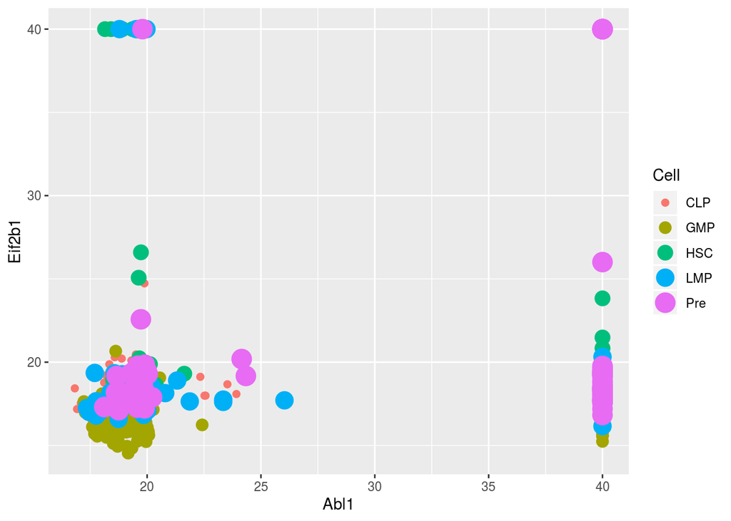

```r
library(ggplot2)

## definition of ggplot data and aesthetics
g <- ggplot(data = transCategories, aes(x=Abl1, y=Eif2b1, colour=Cell, size=Cell))
## Adding geometry layer
g <- g + geom_point()
## plotting
plot(g)
```